## US marginal/unemployment and President’s Terms: Part I

#### August 21, 2016

The Burea of Labor Statistics (BLS) has made good on the Open Data Initiative aims of providing open access to government datasets. Fortunately there is an R language api for the BLS data called “blsscrape”, which I found first on Jason Rickert’s article on [R Packages for Data Access](http://blog.revolutionanalytics.com/2016/08/r-packages-data-access.html) at the *Revolutions* blog.

The blsscrape package is an API wrapper for BLS datasets. Querying and pulling data through R and into project scripts or knitr documents is fast and seamless. I started with two datasets for this project which are described below.

The first step is to load the blsscrape API library and then pull in BLS data by series numbers. Series numbers are listed on the [bls.gov](http://www.bls.gov/news.release/empsit.t15.htm) site.

```r
library(blscrapeR)
bls_94_2000 <- bls_api(c("LNS13327709", "LNS14000000"),
                       startyear = 1994, endyear = 2000)

bls_01_16 <- bls_api(c("LNS13327709", "LNS14000000"),
                    startyear = 2001, endyear = 2016)

bls_full <- rbind(bls_94_2000, bls_01_16)
```

### US Unemployement 1994-2000

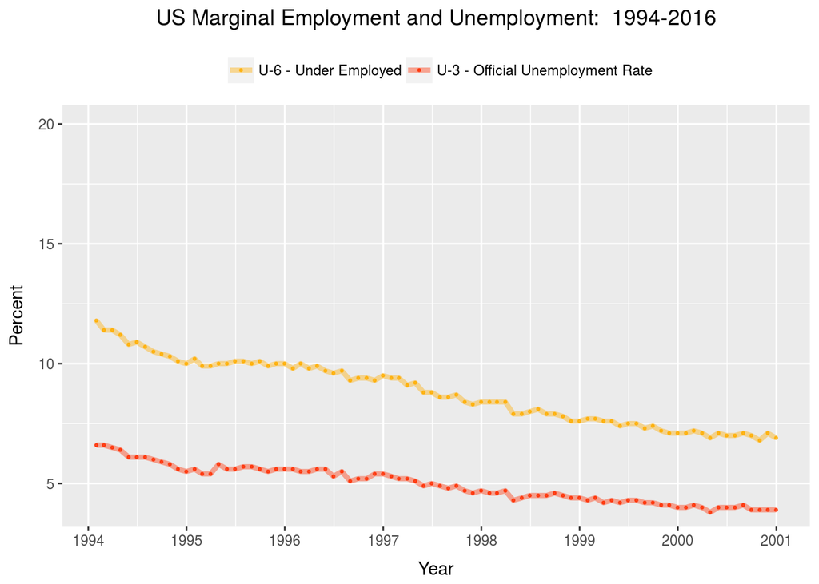

```r
library(ggplot2)

ggplot(data=bls_94_2000, aes(x = date, y = value, color=seriesID)) +
  coord_cartesian(ylim=c(4, 20)) +
  labs(title = "US Marginal Employment and Unemployment:  1994-2016") +
  geom_line(size=1.5, alpha=0.40) +
  geom_point(size=0.5, alpha=0.80) +
  theme(legend.position="top", legend.title=element_blank(),
        axis.title.y = element_text(margin = margin(l = 0, r = 10)),
        axis.title.x = element_text(margin = margin(t = 10))) +
  scale_color_manual(values=c("#ffae00", "#ff2e00"),
                     labels=c("U-6 - Under Employed",
                              "U-3 - Official Unemployment Rate")) +
  scale_x_date(date_breaks = ("1 year"), date_labels = "%Y") +
  xlab("Year") +
  ylab("Percent")
```

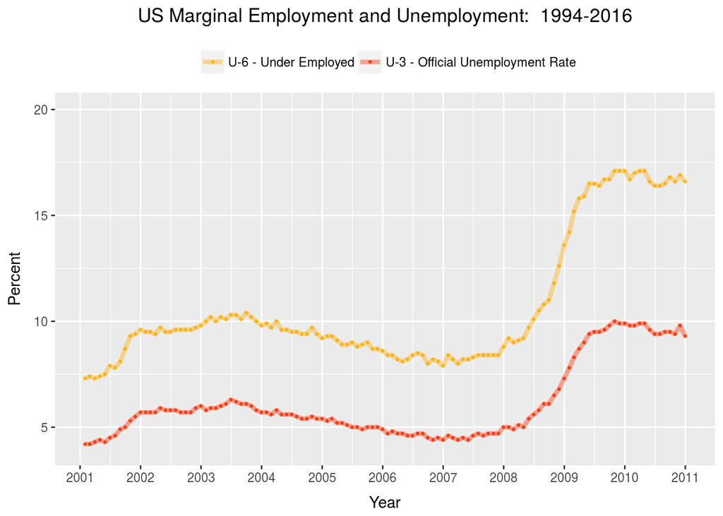

```r
ggplot(data=bls_01_16, aes(x = date, y = value, color=seriesID)) +
  coord_cartesian(ylim=c(4, 20)) +
  labs(title = "US Marginal Employment and Unemployment:  1994-2016") +
  geom_line(size=1.5, alpha=0.40) +
  geom_point(size=0.5, alpha=0.80) +
  theme(legend.position="top", legend.title=element_blank(),
        axis.title.y = element_text(margin = margin(l = 0, r = 10)),
        axis.title.x = element_text(margin = margin(t = 10))) +
  scale_color_manual(values=c("#ffae00", "#ff2e00"),
                     labels=c("U-6 - Under Employed",
                              "U-3 - Official Unemployment Rate")) +
  scale_x_date(date_breaks = ("1 year"), date_labels = "%Y") +
  xlab("Year") +
  ylab("Percent")
```

Up next … Exploratory analysis of marginal employment minus unemployment for years 1994-2016.